# Final Report: Will you survive the Titanic?

> Ajinkya Dhage and Shardul Vinchurkar (Group 9)

# 1. Introduction and Problem Statement

RMS Titanic, a British passenger liner started its journey to the New York City on 10th of April 1912. It collided with a large iceberg on 15th of April 1912 that resulted in the sinking of the largest passenger liner ever made. This tragic accident resulted in deaths of around 1500 people from the reported 2224 passengers on board.

There were many reasons that this incident led to such loss of life, but, amongst all the reasons the main reason was that the number of lifeboats on the ship was not enough to hold all the passengers and crew members. There were certain decisions made while the ship was sinking which was another main reason for this mishap. These decisions were based on the demographics of the passengers, and a certain group of people had a higher chance of survival. Some of the factors that concluded in the survival of certain passengers were Gender, Age and Class/status.

In this project, we propose to develop a model to predict the chance of survival of any given passenger on the Titanic voyage.

# 2. Data sources and data preparation

The data used for analysis of the passengers survived was taken from Kaggle. (https://www.kaggle.com/c/titanic/data)

### 2.1 Data attributes

This training data source has 891 instances, the test data has 418 instances and following 12 attributes/columns.

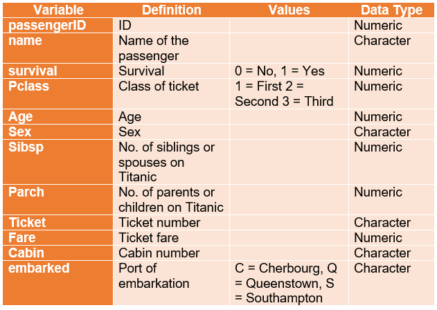

### 2.2 Data Instance

- PassengerId: 1
- Survived: 0
- Pclass: 3
- Name: Braund, Mr. Owen Harris
- Sex: male
- Age: 22
- SibSp: 1
- Parch: 0
- Ticket: A/5 21171
- Fare: $7.25
- Cabin: NA
- Embarked: S

### 2.3 Data preparation

```r
#Loading the data
titanicTrain <- read.csv("train.csv")
titanicTest <- read.csv("test.csv")
head(titanicTrain)
```

|  | PassengerId | Survived | Pclass | Name | Sex | Age | SibSp | Parch | Ticket | Fare | Cabin | Embarked |
| --- | --- | --- | --- | --- | --- | --- | --- | --- | --- | --- | --- | --- |
| 1 | 1 | 0 | 3 | Braund, Mr. Owen Harris | male | 22 | 1 | 0 | A/5 21171 | 7.2500 |  | S |
| 2 | 2 | 1 | 1 | Cumings, Mrs. John Bradley (Florence Briggs Thayer) | female | 38 | 1 | 0 | PC 17599 | 71.2833 | C85 | C |
| 3 | 3 | 1 | 3 | Heikkinen, Miss. Laina | female | 26 | 0 | 0 | STON/O2. 3101282 | 7.9250 |  | S |
| 4 | 4 | 1 | 1 | Futrelle, Mrs. Jacques Heath (Lily May Peel) | female | 35 | 1 | 0 | 113803 | 53.1000 | C123 | S |
| 5 | 5 | 0 | 3 | Allen, Mr. William Henry | male | 35 | 0 | 0 | 373450 | 8.0500 |  | S |
| 6 | 6 | 0 | 3 | Moran, Mr. James | male | NA | 0 | 0 | 330877 | 8.4583 |  | Q |

# 3. Data exploration, visualization, cleansing and transformation

### 3.1 Data Exploration

```r
#Data Exploration
summary(titanicTrain)
```

```
  PassengerId       Survived          Pclass                                         Name
 Min.   :  1.0   Min.   :0.0000   Min.   :1.000   Abbing, Mr. Anthony                  :  1
 1st Qu.:223.5   1st Qu.:0.0000   1st Qu.:2.000   Abbott, Mr. Rossmore Edward          :  1
 Median :446.0   Median :0.0000   Median :3.000   Abbott, Mrs. Stanton (Rosa Hunt)     :  1
 Mean   :446.0   Mean   :0.3838   Mean   :2.309   Abelson, Mr. Samuel                  :  1
 3rd Qu.:668.5   3rd Qu.:1.0000   3rd Qu.:3.000   Abelson, Mrs. Samuel (Hannah Wizosky):  1
 Max.   :891.0   Max.   :1.0000   Max.   :3.000   Adahl, Mr. Mauritz Nils Martin       :  1
                                                  (Other)                              :885
     Sex           Age            SibSp           Parch             Ticket         Fare
 female:314   Min.   : 0.42   Min.   :0.000   Min.   :0.0000   1601    :  7   Min.   :  0.00
 male  :577   1st Qu.:20.12   1st Qu.:0.000   1st Qu.:0.0000   347082  :  7   1st Qu.:  7.91
              Median :28.00   Median :0.000   Median :0.0000   CA. 2343:  7   Median : 14.45
              Mean   :29.70   Mean   :0.523   Mean   :0.3816   3101295 :  6   Mean   : 32.20
              3rd Qu.:38.00   3rd Qu.:1.000   3rd Qu.:0.0000   347088  :  6   3rd Qu.: 31.00
              Max.   :80.00   Max.   :8.000   Max.   :6.0000   CA 2144 :  6   Max.   :512.33
              NA's   :177                                      (Other) :852
         Cabin     Embarked
            :687    :  2
 B96 B98    :  4   C:168
 C23 C25 C27:  4   Q: 77
 G6         :  4   S:644
 C22 C26    :  3
 D          :  3
 (Other)    :186
```

```r
summary(titanicTest)
```

```
  PassengerId         Pclass                                             Name         Sex
 Min.   : 892.0   Min.   :1.000   Abbott, Master. Eugene Joseph            :  1   female:152
 1st Qu.: 996.2   1st Qu.:1.000   Abelseth, Miss. Karen Marie              :  1   male  :266
 Median :1100.5   Median :3.000   Abelseth, Mr. Olaus Jorgensen            :  1
 Mean   :1100.5   Mean   :2.266   Abrahamsson, Mr. Abraham August Johannes :  1
 3rd Qu.:1204.8   3rd Qu.:3.000   Abrahim, Mrs. Joseph (Sophie Halaut Easu):  1
 Max.   :1309.0   Max.   :3.000   Aks, Master. Philip Frank                :  1
                                  (Other)                                  :412
      Age            SibSp            Parch             Ticket         Fare
 Min.   : 0.17   Min.   :0.0000   Min.   :0.0000   PC 17608:  5   Min.   :  0.000
 1st Qu.:21.00   1st Qu.:0.0000   1st Qu.:0.0000   113503  :  4   1st Qu.:  7.896
 Median :27.00   Median :0.0000   Median :0.0000   CA. 2343:  4   Median : 14.454
 Mean   :30.27   Mean   :0.4474   Mean   :0.3923   16966   :  3   Mean   : 35.627
 3rd Qu.:39.00   3rd Qu.:1.0000   3rd Qu.:0.0000   220845  :  3   3rd Qu.: 31.500
 Max.   :76.00   Max.   :8.0000   Max.   :9.0000   347077  :  3   Max.   :512.329
 NA's   :86                                        (Other) :396   NA's   :1
             Cabin     Embarked
                :327   C:102
 B57 B59 B63 B66:  3   Q: 46
 A34            :  2   S:270
 B45            :  2
 C101           :  2
 C116           :  2
 (Other)        : 80
```

### 3.2 Data Transformation

Our dataset includes 12 attributes among which Pclass is a numerical attribute which needs to be mapped as a nominal value, given that 1 represents the Upper class, 2 for the middle class and 3 for the lower class.

Also, the Survived attribute in the dataset needs to be mapped as a class value of Yes and No.

```r
#Data Extraction and transformation
#COnverting Pclass to nomainal
titanicTrain$Pclass <- factor(titanicTrain$Pclass, levels = c(1, 2, 3), labels = c("Upper", "Middle", "Lower"))
titanicTest$Pclass <- factor(titanicTest$Pclass, levels = c(1, 2, 3), labels = c("Upper", "Middle", "Lower"))
#Converting Survived to nomainal
titanicTrain$Survived <- factor(titanicTrain$Survived, levels = c(1, 0), labels = c("Yes", "No"))
#Adding Survived to Test
titanicTest$Survived <- NA
```

### 3.3 Data Visualization

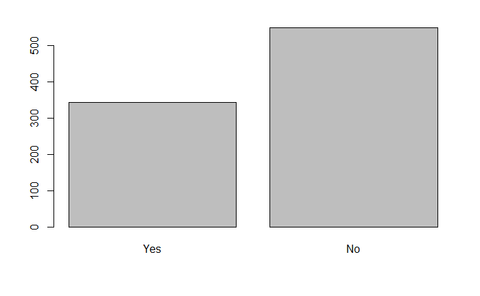

```r
library(ggplot2)
#Data visualization
plot(titanicTrain$Survived)
```

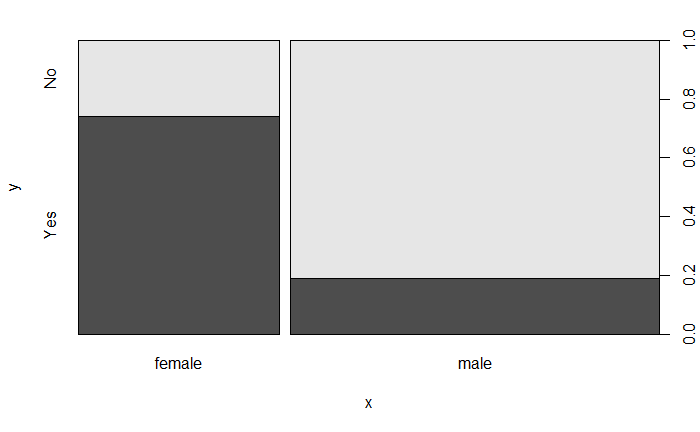

```r
plot(titanicTrain$Sex, titanicTrain$Survived)
```

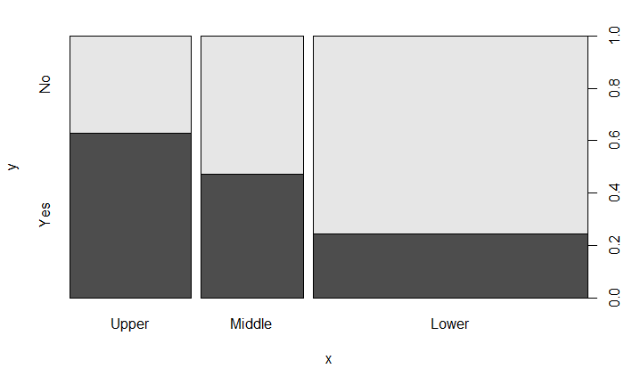

```r
plot(titanicTrain$Pclass, titanicTrain$Survived)
```

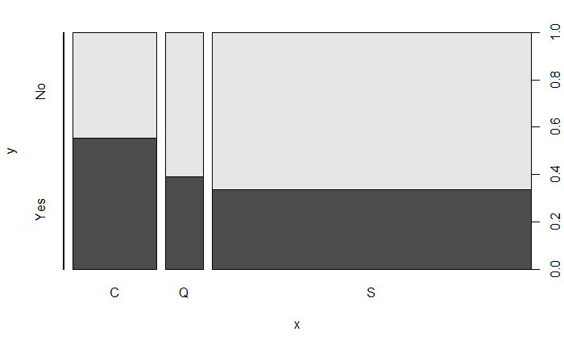

```r
plot(titanicTrain$Embarked, titanicTrain$Survived)
```

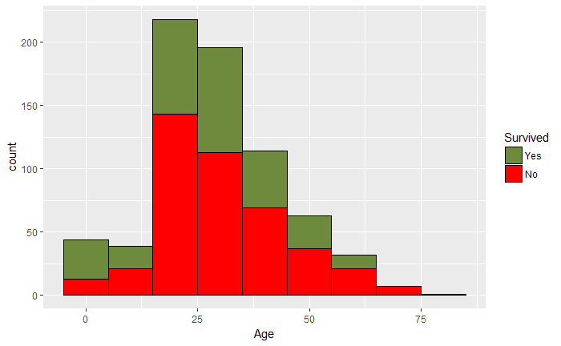

```r
ggplot(titanicTrain, aes(x=Age, fill=Survived, color=Survived)) +
  geom_histogram(binwidth=10, position="stack") +
  scale_color_manual(values=c("black","black")) +
  scale_fill_manual(values=c("darkolivegreen4", "red"))
```

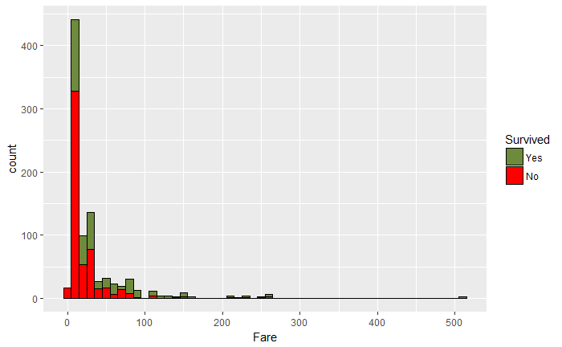

```r
ggplot(titanicTrain, aes(x=Fare, fill=Survived, color=Survived)) +
  geom_histogram(binwidth=10, position="stack") +
  scale_color_manual(values=c("black","black")) +
  scale_fill_manual(values=c("darkolivegreen4", "red"))
```

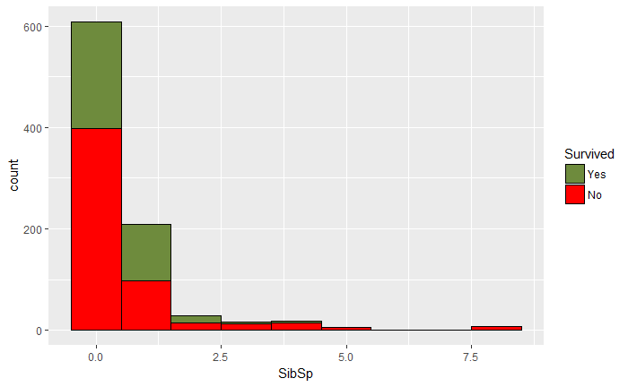

```r
ggplot(titanicTrain, aes(x=SibSp, fill=Survived, color=Survived)) +
  geom_histogram(binwidth=1, position="stack") +
  scale_color_manual(values=c("black","black")) +
  scale_fill_manual(values=c("darkolivegreen4", "red"))
```

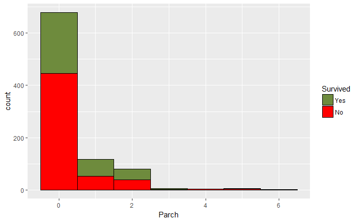

```r
ggplot(titanicTrain, aes(x=Parch, fill=Survived, color=Survived)) +
  geom_histogram(binwidth=1, position="stack") +
  scale_color_manual(values=c("black","black")) +
  scale_fill_manual(values=c("darkolivegreen4", "red"))
```

When we plot the graph for the survival of passengers we can see the probability of the survival of passengers is around 39%. So we, have an understanding that the possibility of survival of a passenger on the Titanic is quite infrequent. Based on this we tried to visualize the effects of different attributes on the chance of survival.

The plot of gender versus the survival clearly indicates that the chance of survival for women passengers is much higher than that of the male passengers. This helps us realize that the attribute gender is of utmost importance, and needs to be included in our analysis for predicting the chance of survival of any given passneger.

Next, we wanted to see how the social status of the passenger would have affected the survival rate of onboard population. On plotting the graph we can clearly see that the chance of survival is higher for upper-class passengers, as compared to the middle class and lower class. Also, the chance of survival for the lower class is far less than that of any other class.

Then we wanted to confirm how the survival rate is affected by the age of the passengers. So plotting the graph we realize that children and passengers within 9 - 40 age range had a fair chance of survival as compared to old people or people above the age of 55. Thus, helping us understand the importance of the attribute age in our analysis.

There are 2 attributes namely the SibSp and the Parch which stands for sibling spouse and parent children, they necessarily determine how many family members are onboard with the passenger. On plotting the graph for SibSp and Parch versus survival, we observed that a medium sized family had a fairer chance of survival as compared to a single person or a passenger traveling with a large family.

There are other 2 attributes fare and port of embarkation, visualizing fare is difficult because the data is continuous and contains outliers for eg. A passenger has paid $512 for his ticket. Similarly, the port of Embarkation represents where the passenger boarded the Titanic, and seem to have a similar effect on the chance of survival.

### 3.4 Data Transformation

So when we summarized our data in initial exploration, we realized that there were a lot of missing values in the dataset. Among these missing values, the Embarked attribute had 2 blank values which were not considered as NA but a whole other type, to overcome this problem we replaced the blank values with NA values and treated them as missing data. Then, we combined the train data and the test data to achieve the consistency throughout the dataset (train and test) while filling the missing values. After which, we combined the attributes SibSp and Parch in one attribute named “Family’ based on our initial observation of visualizing the plot of SibSp Vs Survived and Parch Vs Survived.

```r
#Adding NA to Missing Embarked Data
titanicTrain$Embarked[titanicTrain$Embarked == ""] <- NA
#Combining train and test data
titanicData <- rbind(titanicTrain, titanicTest)
#Data Transformation
titanicData$Family <- titanicData$SibSp + titanicData$Parch
```

### 3.5 Data Cleansing

After the initial exploration and the visualization of the data, we observed that the attribute Ticket has alphanumeric values and does not provide any demographic information about the passenger. Similarly, the attribute Cabin is irrelevant as it contains a lot of blank values and does not represent any information about the passenger. Also since we have combined the columns SibSp and Parch in Family they are no longer useful on our analysis. In the end, the attribute Name also does not contribute much towards the final prediction. Hence, we drop all these columns from our dataset.

```r
#Data Cleaning
drops <- c("Name", "SibSp", "Parch", "Ticket", "Cabin")
titanicData <- titanicData[, !names(titanicData) %in% drops]
summary(titanicData)
```

```
  PassengerId   Survived      Pclass        Sex           Age             Fare         Embarked
 Min.   :   1   Yes :342   Upper :323   female:466   Min.   : 0.17   Min.   :  0.000       :  0
 1st Qu.: 328   No  :549   Middle:277   male  :843   1st Qu.:21.00   1st Qu.:  7.896   C   :270
 Median : 655   NA's:418   Lower :709                Median :28.00   Median : 14.454   Q   :123
 Mean   : 655                                        Mean   :29.88   Mean   : 33.295   S   :914
 3rd Qu.: 982                                        3rd Qu.:39.00   3rd Qu.: 31.275   NA's:  2
 Max.   :1309                                        Max.   :80.00   Max.   :512.329
                                                     NA's   :263     NA's   :1
     Family
 Min.   : 0.0000
 1st Qu.: 0.0000
 Median : 0.0000
 Mean   : 0.8839
 3rd Qu.: 1.0000
 Max.   :10.0000
```

# 4. Methodology

As discussed we have a lot of missing instances in our dataset. The methodology we will be following here would be as follows:

- **Using different cleansing methods to fill in the missing values**
  - **Mean:** In this method, we will calculate the mean of the attribute and assign it to all the missing values in that attribute.
  - **KNN:** The KNN algorithm in R predicts the missing values by grouping the data instance based on Euclidean distance.
  - **Linear regression:** We will build a predictive model using regression to predict the missing values in our data.
- **For each cleansing method we will build different models**
  - Naive Bayes
  - Decision Tree
  - SVM
  - Random Forest
  - General Linear Model

# 5. Modelling

### 5.1 Method 1

Using Mean values to fill missing instances of the data.

```r
#data Cleaning
method1Data <- titanicData
#Filling the missing values using Mean
ageMean <- mean(method1Data$Age, na.rm = T)
fareMean <- mean(method1Data$Fare, na.rm = T)
method1Data$Age[is.na(method1Data$Age)] <- ageMean
method1Data$Fare[is.na(method1Data$Fare)] <- fareMean
method1Data$Embarked[is.na(method1Data$Embarked)] <- "S"
summary(method1Data)
```

```
  PassengerId   Survived      Pclass        Sex           Age             Fare         Embarked
 Min.   :   1   Yes :342   Upper :323   female:466   Min.   : 0.17   Min.   :  0.000    :  0
 1st Qu.: 328   No  :549   Middle:277   male  :843   1st Qu.:22.00   1st Qu.:  7.896   C:270
 Median : 655   NA's:418   Lower :709                Median :29.88   Median : 14.454   Q:123
 Mean   : 655                                        Mean   :29.88   Mean   : 33.295   S:916
 3rd Qu.: 982                                        3rd Qu.:35.00   3rd Qu.: 31.275
 Max.   :1309                                        Max.   :80.00   Max.   :512.329
     Family
 Min.   : 0.0000
 1st Qu.: 0.0000
 Median : 0.0000
 Mean   : 0.8839
 3rd Qu.: 1.0000
 Max.   :10.0000
```

```r
method1DataTrain <- method1Data[!is.na(method1Data$Survived),]
method1DataTest <- method1Data[is.na(method1Data$Survived),]
```

```r
#Generating the training set
method1Rows <- sample(0.90 * nrow(method1DataTrain))
method1Train <- method1DataTrain[method1Rows, ]
method1Test <- method1DataTrain[-method1Rows, ]
```

```r
summary(method1Train)
```

```
  PassengerId  Survived     Pclass        Sex           Age             Fare         Embarked
 Min.   :  1   Yes:308   Upper :195   female:283   Min.   : 0.67   Min.   :  0.000    :  0
 1st Qu.:201   No :493   Middle:167   male  :518   1st Qu.:22.00   1st Qu.:  7.925   C:149
 Median :401             Lower :439                Median :29.88   Median : 14.500   Q: 73
 Mean   :401                                       Mean   :29.88   Mean   : 33.014   S:579
 3rd Qu.:601                                       3rd Qu.:35.00   3rd Qu.: 31.275
 Max.   :801                                       Max.   :80.00   Max.   :512.329
     Family
 Min.   : 0.0000
 1st Qu.: 0.0000
 Median : 0.0000
 Mean   : 0.8914
 3rd Qu.: 1.0000
 Max.   :10.0000
```

```r
summary(method1Test)
```

```
  PassengerId    Survived    Pclass       Sex          Age             Fare         Embarked
 Min.   :802.0   Yes:34   Upper :21   female:31   Min.   : 0.42   Min.   :  0.000    : 0
 1st Qu.:824.2   No :56   Middle:17   male  :59   1st Qu.:21.00   1st Qu.:  7.896   C:19
 Median :846.5            Lower :52               Median :29.88   Median : 12.738   Q: 4
 Mean   :846.5                                    Mean   :28.46   Mean   : 25.001   S:67
 3rd Qu.:868.8                                    3rd Qu.:34.12   3rd Qu.: 30.000
 Max.   :891.0                                    Max.   :74.00   Max.   :164.867
     Family
 Min.   : 0.000
 1st Qu.: 0.000
 Median : 0.000
 Mean   : 1.022
 3rd Qu.: 1.000
 Max.   :10.000
```

#### 5.1.1 Naive Bayes

```r
library(e1071)
method1NB <- naiveBayes(Survived ~ Pclass + Sex + Age + Fare + Family, method1Train)
method1NB
```

```
Naive Bayes Classifier for Discrete Predictors

Call:
naiveBayes.default(x = X, y = Y, laplace = laplace)

A-priori probabilities:
Y
      Yes        No
0.3845194 0.6154806

Conditional probabilities:
     Pclass
Y         Upper    Middle     Lower
  Yes 0.3896104 0.2597403 0.3506494
  No  0.1521298 0.1764706 0.6713996

     Sex
Y        female      male
  Yes 0.6850649 0.3149351
  No  0.1460446 0.8539554

     Age
Y         [,1]     [,2]
  Yes 28.58635 13.55978
  No  30.68550 12.53221

     Fare
Y         [,1]     [,2]
  Yes 49.34432 69.06396
  No  22.81091 32.62888

     Family
Y          [,1]     [,2]
  Yes 0.9350649 1.211645
  No  0.8640974 1.761083
```

```r
method1NBPred <- predict(method1NB, method1Test)
confusion <- table(Prediction = method1NBPred, Actual = method1Test$Survived)
confusion
```

```
          Actual
Prediction Yes No
       Yes  21  2
       No   13 54
```

```r
#Evaluation of model
TN <- confusion["No", "No"]
FN <- confusion["No", "Yes"]
TP <- confusion["Yes", "Yes"]
FP <- confusion["Yes", "No"]
nbAccuracy <- (TP + TN) / (TP + TN + FP + FN) #Accuracy
nbPrecision <- TP / (TP + FP) #Precision
nbRecall <- TP / (TP + FN) #Recall
nbF <- nbPrecision * nbRecall * 2/(nbPrecision + nbRecall) #F-Measure
#Computing the Chance Agreement
p1e <- (TN + FN)/(TP + TN + FP + FN) * (TN + FP)/(TP + TN + FP + FN)
p2e <- (TP + FP)/(TP + TN + FP + FN) * (TP + FN)/(TP + TN + FP + FN)
pe <- p1e + p2e
nbKappa <- (nbAccuracy - pe)/(1 - pe) #Kappa
nbAccuracy
```

```
[1] 0.8333333
```

```r
nbPrecision
```

```
[1] 0.9130435
```

```r
nbRecall
```

```
[1] 0.6176471
```

```r
nbF
```

```
[1] 0.7368421
```

```r
nbKappa
```

```
[1] 0.6214246
```

#### 5.1.2 Decision Tree

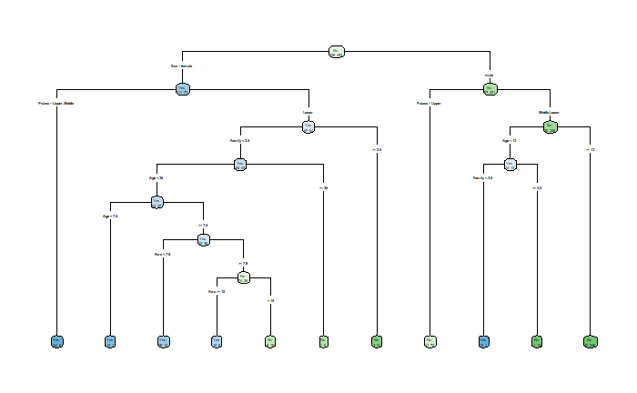

```r
library(rpart)
library(rpart.plot)
method1DT <- rpart(Survived ~ Pclass + Sex + Age + Fare + Embarked + Family, method1Train)
rpart.plot(method1DT, type = 4, extra = 1)
```

```r
dtPred <- predict(method1DT, method1Test, type = "class")
confusion <- table(Prediction = dtPred, Actual = method1Test$Survived)
confusion
```

```
          Actual
Prediction Yes No
       Yes  23  4
       No   11 52
```

```r
#Evaluation of model
TN <- confusion["No", "No"]
FN <- confusion["No", "Yes"]
TP <- confusion["Yes", "Yes"]
FP <- confusion["Yes", "No"]
dtAccuracy <- (TP + TN) / (TP + TN + FP + FN) #Accuracy
dtPrecision <- TP / (TP + FP) #Precision
dtRecall <- TP / (TP + FN) #Recall
dtF <- dtPrecision * dtRecall * 2/(dtPrecision + dtRecall) #F-Measure
#Computing the Chance Agreement
p1e <- (TN + FN)/(TP + TN + FP + FN) * (TN + FP)/(TP + TN + FP + FN)
p2e <- (TP + FP)/(TP + TN + FP + FN) * (TP + FN)/(TP + TN + FP + FN)
pe <- p1e + p2e
dtKappa <- (dtAccuracy - pe)/(1 - pe) #Kappa
dtAccuracy
```

```
[1] 0.8333333
```

```r
dtPrecision
```

```
[1] 0.8518519
```

```r
dtRecall
```

```
[1] 0.6764706
```

```r
dtF
```

```
[1] 0.7540984
```

```r
dtKappa
```

```
[1] 0.6305419
```

#### 5.1.3 SVM

```r
method1SVM <- svm(Survived ~ Pclass + Sex + Age + Fare + Embarked + Family, method1Train)
#Generating the prediction
svmPrediction <- predict(method1SVM, method1Test, type = "class")
#Builing the Confusion Matrix
confusion <- table(Prediction = svmPrediction, Actual = method1Test$Survived)
confusion
```

```
          Actual
Prediction Yes No
       Yes  26  5
       No    8 51
```

```r
#Evaluation of model
TN <- confusion["No", "No"]
FN <- confusion["No", "Yes"]
TP <- confusion["Yes", "Yes"]
FP <- confusion["Yes", "No"]
svmAccuracy = (TP + TN) / (TP + TN + FP + FN) #Accuracy
svmPrecision = TP / (TP + FP) #Precision
svmRecall = TP / (TP + FN) #Recall
svmF = svmPrecision * svmRecall * 2/(svmPrecision + svmRecall) #F-Measure
#Computing the Chance Agreement
p1e = (TN + FN)/(TP + TN + FP + FN) * (TN + FP)/(TP + TN + FP + FN)
p2e = (TP + FP)/(TP + TN + FP + FN) * (TP + FN)/(TP + TN + FP + FN)
pe = p1e + p2e
svmKappa = (svmAccuracy - pe)/(1 - pe) #Kappa
svmAccuracy
```

```
[1] 0.8555556
```

```r
svmPrecision
```

```
[1] 0.8387097
```

```r
svmRecall
```

```
[1] 0.7647059
```

```r
svmF
```

```
[1] 0.8
```

```r
svmKappa
```

```
[1] 0.687333
```

#### 5.1.4 Random Forest

```r
library(randomForest)
method1RF <- randomForest(Survived ~ Pclass + Sex + Age + Fare + Embarked + Family, method1Train)
#Generating the prediction
rfPrediction <- predict(method1RF, method1Test, type = "class")
#Builing the Confusion Matrix
confusion <- table(Prediction = rfPrediction, Actual = method1Test$Survived)
confusion
```

```
          Actual
Prediction Yes No
       Yes  26  7
       No    8 49
```

```r
#Evaluation of model
TN <- confusion["No", "No"]
FN <- confusion["No", "Yes"]
TP <- confusion["Yes", "Yes"]
FP <- confusion["Yes", "No"]
rfAccuracy = (TP + TN) / (TP + TN + FP + FN) #Accuracy
rfPrecision = TP / (TP + FP) #Precision
rfRecall = TP / (TP + FN) #Recall
rfF = rfPrecision * rfRecall * 2/(rfPrecision + rfRecall) #F-Measure
#Computing the Chance Agreement
p1e = (TN + FN)/(TP + TN + FP + FN) * (TN + FP)/(TP + TN + FP + FN)
p2e = (TP + FP)/(TP + TN + FP + FN) * (TP + FN)/(TP + TN + FP + FN)
pe = p1e + p2e
rfKappa = (rfAccuracy - pe)/(1 - pe) #Kappa
rfAccuracy
```

```
[1] 0.8333333
```

```r
rfPrecision
```

```
[1] 0.7878788
```

```r
rfRecall
```

```
[1] 0.7647059
```

```r
rfF
```

```
[1] 0.7761194
```

```r
rfKappa
```

```
[1] 0.6434231
```

#### 5.1.5 General Linear Model

```r
library(caTools)
#Builing the method1
method1Lr <- glm(Survived ~ Pclass + Sex + Age + Fare + Embarked + Family, method1Train, family = binomial)
#Generating the prediction
lrPrediction <- ifelse(predict(method1Lr,method1Test, type = 'response') > 0.5, 'No', 'Yes')
#Builing the Confusion Matrix
confusion <- table(Prediction = lrPrediction, Actual = method1Test$Survived)
confusion
```

```
          Actual
Prediction Yes No
       No    9 50
       Yes  25  6
```

```r
#Evaluation of method1
TN <- confusion["No", "No"]
FN <- confusion["No", "Yes"]
TP <- confusion["Yes", "Yes"]
FP <- confusion["Yes", "No"]
lrAccuracy = (TP + TN) / (TP + TN + FP + FN) #Accuracy
lrPrecision = TP / (TP + FP) #Precision
lrRecall = TP / (TP + FN) #Recall
lrF = lrPrecision * lrRecall * 2/(lrPrecision + lrRecall) #F-Measure
#Computing the Chance Agreement
p1e = (TN + FN)/(TP + TN + FP + FN) * (TN + FP)/(TP + TN + FP + FN)
p2e = (TP + FP)/(TP + TN + FP + FN) * (TP + FN)/(TP + TN + FP + FN)
pe = p1e + p2e
lrKappa = (lrAccuracy - pe)/(1 - pe) #Kappa
lrAccuracy
```

```
[1] 0.8333333
```

```r
lrPrecision
```

```
[1] 0.8064516
```

```r
lrRecall
```

```
[1] 0.7352941
```

```r
lrF
```

```
[1] 0.7692308
```

```r
lrKappa
```

```
[1] 0.6392304
```

### 5.2 Method 2

Using KNN to fill missing instances of the data.

```r
#data Cleaning
method2Data <- titanicData
library(VIM)
cols <- c("Pclass", "Sex", "Age", "Fare", "Embarked", "Family")
method2Data <- kNN(method2Data, cols, k = 37)
summary(method2Data)
```

```
  PassengerId   Survived      Pclass        Sex           Age             Fare         Embarked
 Min.   :   1   Yes :342   Upper :323   female:466   Min.   : 0.17   Min.   :  0.000    :  0
 1st Qu.: 328   No  :549   Middle:277   male  :843   1st Qu.:22.00   1st Qu.:  7.896   C:270
 Median : 655   NA's:418   Lower :709                Median :28.00   Median : 14.454   Q:123
 Mean   : 655                                        Mean   :29.33   Mean   : 33.290   S:916
 3rd Qu.: 982                                        3rd Qu.:35.00   3rd Qu.: 31.275
 Max.   :1309                                        Max.   :80.00   Max.   :512.329
     Family        Pclass_imp       Sex_imp         Age_imp         Fare_imp       Embarked_imp
 Min.   : 0.0000   Mode :logical   Mode :logical   Mode :logical   Mode :logical   Mode :logical
 1st Qu.: 0.0000   FALSE:1309      FALSE:1309      FALSE:1046      FALSE:1308      FALSE:1307
 Median : 0.0000                                   TRUE :263       TRUE :1         TRUE :2
 Mean   : 0.8839
 3rd Qu.: 1.0000
 Max.   :10.0000
 Family_imp
 Mode :logical
 FALSE:1309
```

```r
knndrops <- c("Pclass_imp", "Sex_imp", "Age_imp", "Fare_imp", "Embarked_imp", "Family_imp")
method2Data <- method2Data[, !names(method2Data) %in% knndrops]
summary(method2Data)
```

```
  PassengerId   Survived      Pclass        Sex           Age             Fare         Embarked
 Min.   :   1   Yes :342   Upper :323   female:466   Min.   : 0.17   Min.   :  0.000    :  0
 1st Qu.: 328   No  :549   Middle:277   male  :843   1st Qu.:22.00   1st Qu.:  7.896   C:270
 Median : 655   NA's:418   Lower :709                Median :28.00   Median : 14.454   Q:123
 Mean   : 655                                        Mean   :29.33   Mean   : 33.290   S:916
 3rd Qu.: 982                                        3rd Qu.:35.00   3rd Qu.: 31.275
 Max.   :1309                                        Max.   :80.00   Max.   :512.329
     Family
 Min.   : 0.0000
 1st Qu.: 0.0000
 Median : 0.0000
 Mean   : 0.8839
 3rd Qu.: 1.0000
 Max.   :10.0000
```

```r
method2Data$Family <-cut(method2Data$Family, c(0,1,5,11), right=FALSE, labels=c("Single", "Medium", "Large"))
summary(method2Data)
```

```
  PassengerId   Survived      Pclass        Sex           Age             Fare         Embarked
 Min.   :   1   Yes :342   Upper :323   female:466   Min.   : 0.17   Min.   :  0.000    :  0
 1st Qu.: 328   No  :549   Middle:277   male  :843   1st Qu.:22.00   1st Qu.:  7.896   C:270
 Median : 655   NA's:418   Lower :709                Median :28.00   Median : 14.454   Q:123
 Mean   : 655                                        Mean   :29.33   Mean   : 33.290   S:916
 3rd Qu.: 982                                        3rd Qu.:35.00   3rd Qu.: 31.275
 Max.   :1309                                        Max.   :80.00   Max.   :512.329
    Family
 Single:790
 Medium:459
 Large : 60
```

```r
method2DataTrain <- method2Data[!is.na(method2Data$Survived),]
method2DataTest <- method2Data[is.na(method2Data$Survived),]
```

```r
#Generating the training set
method2Rows <- sample(0.90 * nrow(method2DataTrain))
method2Train <- method2DataTrain[method2Rows, ]
method2Test <- method2DataTrain[-method2Rows, ]
```

```r
summary(method2Train)
```

```
  PassengerId  Survived     Pclass        Sex           Age             Fare         Embarked
 Min.   :  1   Yes:308   Upper :195   female:283   Min.   : 0.67   Min.   :  0.000    :  0
 1st Qu.:201   No :493   Middle:167   male  :518   1st Qu.:22.00   1st Qu.:  7.925   C:149
 Median :401             Lower :439                Median :29.00   Median : 14.500   Q: 73
 Mean   :401                                       Mean   :29.56   Mean   : 33.014   S:579
 3rd Qu.:601                                       3rd Qu.:35.00   3rd Qu.: 31.275
 Max.   :801                                       Max.   :80.00   Max.   :512.329
    Family
 Single:482
 Medium:279
 Large : 40
```

```r
summary(method2Test)
```

```
  PassengerId    Survived    Pclass       Sex          Age             Fare         Embarked
 Min.   :802.0   Yes:34   Upper :21   female:31   Min.   : 0.42   Min.   :  0.000    : 0
 1st Qu.:824.2   No :56   Middle:17   male  :59   1st Qu.:20.00   1st Qu.:  7.896   C:19
 Median :846.5            Lower :52               Median :27.00   Median : 12.738   Q: 4
 Mean   :846.5                                    Mean   :27.93   Mean   : 25.001   S:67
 3rd Qu.:868.8                                    3rd Qu.:34.12   3rd Qu.: 30.000
 Max.   :891.0                                    Max.   :74.00   Max.   :164.867
    Family
 Single:55
 Medium:28
 Large : 7
```

#### 5.2.1 Naive Bayes

```r
library(e1071)
method2NB <- naiveBayes(Survived ~ Pclass + Sex + Age + Fare + Family, method2Train)
method2NB
```

```
Naive Bayes Classifier for Discrete Predictors

Call:
naiveBayes.default(x = X, y = Y, laplace = laplace)

A-priori probabilities:
Y
      Yes        No
0.3845194 0.6154806

Conditional probabilities:
     Pclass
Y         Upper    Middle     Lower
  Yes 0.3896104 0.2597403 0.3506494
  No  0.1521298 0.1764706 0.6713996

     Sex
Y        female      male
  Yes 0.6850649 0.3149351
  No  0.1460446 0.8539554

     Age
Y         [,1]     [,2]
  Yes 28.41695 13.63511
  No  30.26876 12.73356

     Fare
Y         [,1]     [,2]
  Yes 49.34432 69.06396
  No  22.81091 32.62888

     Family
Y         Single     Medium      Large
  Yes 0.48701299 0.49025974 0.02272727
  No  0.67342799 0.25963489 0.06693712
```

```r
method2NBPred <- predict(method2NB, method2Test)
confusion <- table(Prediction = method2NBPred, Actual = method2Test$Survived)
confusion
```

```
          Actual
Prediction Yes No
       Yes  22  3
       No   12 53
```

```r
#Evaluation of model
TN <- confusion["No", "No"]
FN <- confusion["No", "Yes"]
TP <- confusion["Yes", "Yes"]
FP <- confusion["Yes", "No"]
nbAccuracy <- (TP + TN) / (TP + TN + FP + FN) #Accuracy
nbPrecision <- TP / (TP + FP) #Precision
nbRecall <- TP / (TP + FN) #Recall
nbF <- nbPrecision * nbRecall * 2/(nbPrecision + nbRecall) #F-Measure
#Computing the Chance Agreement
p1e <- (TN + FN)/(TP + TN + FP + FN) * (TN + FP)/(TP + TN + FP + FN)
p2e <- (TP + FP)/(TP + TN + FP + FN) * (TP + FN)/(TP + TN + FP + FN)
pe <- p1e + p2e
nbKappa <- (nbAccuracy - pe)/(1 - pe) #Kappa
nbAccuracy
```

```
[1] 0.8333333
```

```r
nbPrecision
```

```
[1] 0.88
```

```r
nbRecall
```

```
[1] 0.6470588
```

```r
nbF
```

```
[1] 0.7457627
```

```r
nbKappa
```

```
[1] 0.6260388
```

#### 5.2.2 Decision Tree

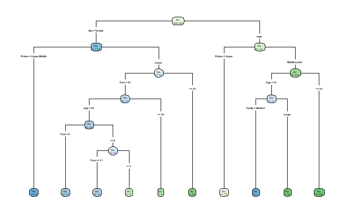

```r
library(rpart)
library(rpart.plot)
method2DT <- rpart(Survived ~ Pclass + Sex + Age + Fare + Embarked + Family, method2Train)
rpart.plot(method2DT, type = 4, extra = 1)
```

```r
dtPred <- predict(method2DT, method2Test, type = "class")
confusion <- table(Prediction = dtPred, Actual = method2Test$Survived)
confusion
```

```
          Actual
Prediction Yes No
       Yes  25  5
       No    9 51
```

```r
#Evaluation of model
TN <- confusion["No", "No"]
FN <- confusion["No", "Yes"]
TP <- confusion["Yes", "Yes"]
FP <- confusion["Yes", "No"]
dtAccuracy <- (TP + TN) / (TP + TN + FP + FN) #Accuracy
dtPrecision <- TP / (TP + FP) #Precision
dtRecall <- TP / (TP + FN) #Recall
dtF <- dtPrecision * dtRecall * 2/(dtPrecision + dtRecall) #F-Measure
#Computing the Chance Agreement
p1e <- (TN + FN)/(TP + TN + FP + FN) * (TN + FP)/(TP + TN + FP + FN)
p2e <- (TP + FP)/(TP + TN + FP + FN) * (TP + FN)/(TP + TN + FP + FN)
pe <- p1e + p2e
dtKappa <- (dtAccuracy - pe)/(1 - pe) #Kappa
dtAccuracy
```

```
[1] 0.8444444
```

```r
dtPrecision
```

```
[1] 0.8333333
```

```r
dtRecall
```

```
[1] 0.7352941
```

```r
dtF
```

```
[1] 0.78125
```

```r
dtKappa
```

```
[1] 0.6612903
```

#### 5.2.3 SVM

```r
method2SVM <- svm(Survived ~ Pclass + Sex + Age + Fare + Embarked + Family, method2Train)
#Generating the prediction
svmPrediction <- predict(method2SVM, method2Test, type = "class")
#Builing the Confusion Matrix
confusion <- table(Prediction = svmPrediction, Actual = method2Test$Survived)
confusion
```

```
          Actual
Prediction Yes No
       Yes  25  7
       No    9 49
```

```r
#Evaluation of model
TN <- confusion["No", "No"]
FN <- confusion["No", "Yes"]
TP <- confusion["Yes", "Yes"]
FP <- confusion["Yes", "No"]
svmAccuracy = (TP + TN) / (TP + TN + FP + FN) #Accuracy
svmPrecision = TP / (TP + FP) #Precision
svmRecall = TP / (TP + FN) #Recall
svmF = svmPrecision * svmRecall * 2/(svmPrecision + svmRecall) #F-Measure
#Computing the Chance Agreement
p1e = (TN + FN)/(TP + TN + FP + FN) * (TN + FP)/(TP + TN + FP + FN)
p2e = (TP + FP)/(TP + TN + FP + FN) * (TP + FN)/(TP + TN + FP + FN)
pe = p1e + p2e
svmKappa = (svmAccuracy - pe)/(1 - pe) #Kappa
svmAccuracy
```

```
[1] 0.8222222
```

```r
svmPrecision
```

```
[1] 0.78125
```

```r
svmRecall
```

```
[1] 0.7352941
```

```r
svmF
```

```
[1] 0.7575758
```

```r
svmKappa
```

```
[1] 0.6174283
```

#### 5.2.4 Random Forest

```r
library(randomForest)
method2RF <- randomForest(Survived ~ Pclass + Sex + Age + Fare + Embarked + Family, method2Train)
#Generating the prediction
rfPrediction <- predict(method2RF, method2Test, type = "class")
#Builing the Confusion Matrix
confusion <- table(Prediction = rfPrediction, Actual = method2Test$Survived)
confusion
```

```
          Actual
Prediction Yes No
       Yes  25  6
       No    9 50
```

```r
#Evaluation of model
TN <- confusion["No", "No"]
FN <- confusion["No", "Yes"]
TP <- confusion["Yes", "Yes"]
FP <- confusion["Yes", "No"]
rfAccuracy = (TP + TN) / (TP + TN + FP + FN) #Accuracy
rfPrecision = TP / (TP + FP) #Precision
rfRecall = TP / (TP + FN) #Recall
rfF = rfPrecision * rfRecall * 2/(rfPrecision + rfRecall) #F-Measure
#Computing the Chance Agreement
p1e = (TN + FN)/(TP + TN + FP + FN) * (TN + FP)/(TP + TN + FP + FN)
p2e = (TP + FP)/(TP + TN + FP + FN) * (TP + FN)/(TP + TN + FP + FN)
pe = p1e + p2e
rfKappa = (rfAccuracy - pe)/(1 - pe) #Kappa
rfAccuracy
```

```
[1] 0.8333333
```

```r
rfPrecision
```

```
[1] 0.8064516
```

```r
rfRecall
```

```
[1] 0.7352941
```

```r
rfF
```

```
[1] 0.7692308
```

```r
rfKappa
```

```
[1] 0.6392304
```

#### 5.2.5 General Linear Model

```r
library(caTools)
#Builing the method2
method2Lr <- glm(Survived ~ Pclass + Sex + Age + Fare + Embarked + Family, method2Train, family = binomial)
#Generating the prediction
lrPrediction <- ifelse(predict(method2Lr,method2Test, type = 'response') > 0.5, 'No', 'Yes')
#Builing the Confusion Matrix
confusion <- table(Prediction = lrPrediction, Actual = method2Test$Survived)
confusion
```

```
          Actual
Prediction Yes No
       No    8 50
       Yes  26  6
```

```r
#Evaluation of method2
TN <- confusion["No", "No"]
FN <- confusion["No", "Yes"]
TP <- confusion["Yes", "Yes"]
FP <- confusion["Yes", "No"]
lrAccuracy = (TP + TN) / (TP + TN + FP + FN) #Accuracy
lrPrecision = TP / (TP + FP) #Precision
lrRecall = TP / (TP + FN) #Recall
lrF = lrPrecision * lrRecall * 2/(lrPrecision + lrRecall) #F-Measure
#Computing the Chance Agreement
p1e = (TN + FN)/(TP + TN + FP + FN) * (TN + FP)/(TP + TN + FP + FN)
p2e = (TP + FP)/(TP + TN + FP + FN) * (TP + FN)/(TP + TN + FP + FN)
pe = p1e + p2e
lrKappa = (lrAccuracy - pe)/(1 - pe) #Kappa
lrAccuracy
```

```
[1] 0.8444444
```

```r
lrPrecision
```

```
[1] 0.8125
```

```r
lrRecall
```

```
[1] 0.7647059
```

```r
lrF
```

```
[1] 0.7878788
```

```r
lrKappa
```

```
[1] 0.6652497
```

### 5.3 Method 3

Using Linear Regression to fill missing instances of the data.

```r
method3Data <- titanicData
fareMedian <- median(method3Data$Fare, na.rm = T)
method3Data$Fare[is.na(method3Data$Fare)] <- fareMedian
method3Data$Embarked[is.na(method3Data$Embarked)] <- "S"
method3Data$Family <- cut(method3Data$Family, c(0,1,5,11), right=FALSE, labels=c("Single", "Medium", "Large"))
lrAge <- lm(Age ~ Pclass + Sex + Embarked + Family, method3Data)
missingAgeData <- method3Data[is.na(method3Data$Age), c("Pclass", "Sex", "Embarked", "Family")]
predictedAge <- predict(lrAge, missingAgeData)
method3Data$Age[is.na(method3Data$Age)] <- predictedAge
summary(method3Data)
```

```
  PassengerId   Survived      Pclass        Sex           Age             Fare         Embarked
 Min.   :   1   Yes :342   Upper :323   female:466   Min.   : 0.17   Min.   :  0.000    :  0
 1st Qu.: 328   No  :549   Middle:277   male  :843   1st Qu.:22.00   1st Qu.:  7.896   C:270
 Median : 655   NA's:418   Lower :709                Median :27.66   Median : 14.454   Q:123
 Mean   : 655                                        Mean   :29.61   Mean   : 33.281   S:916
 3rd Qu.: 982                                        3rd Qu.:36.00   3rd Qu.: 31.275
 Max.   :1309                                        Max.   :80.00   Max.   :512.329
    Family
 Single:790
 Medium:459
 Large : 60
```

```r
method3DataTrain <- method3Data[!is.na(method3Data$Survived),]
method3DataTest <- method3Data[is.na(method3Data$Survived),]
```

```r
#Generating the training set
method3Rows <- sample(0.90 * nrow(method3DataTrain))
method3Train <- method3DataTrain[method3Rows, ]
method3Test <- method3DataTrain[-method3Rows, ]
```

```r
summary(method3Train)
```

```
  PassengerId  Survived     Pclass        Sex           Age             Fare         Embarked
 Min.   :  1   Yes:308   Upper :195   female:283   Min.   : 0.67   Min.   :  0.000    :  0
 1st Qu.:201   No :493   Middle:167   male  :518   1st Qu.:22.00   1st Qu.:  7.925   C:149
 Median :401             Lower :439                Median :27.66   Median : 14.500   Q: 73
 Mean   :401                                       Mean   :29.68   Mean   : 33.014   S:579
 3rd Qu.:601                                       3rd Qu.:36.00   3rd Qu.: 31.275
 Max.   :801                                       Max.   :80.00   Max.   :512.329
    Family
 Single:482
 Medium:279
 Large : 40
```

```r
summary(method3Test)
```

```
  PassengerId    Survived    Pclass       Sex          Age             Fare         Embarked
 Min.   :802.0   Yes:34   Upper :21   female:31   Min.   : 0.42   Min.   :  0.000    : 0
 1st Qu.:824.2   No :56   Middle:17   male  :59   1st Qu.:20.00   1st Qu.:  7.896   C:19
 Median :846.5            Lower :52               Median :27.66   Median : 12.738   Q: 4
 Mean   :846.5                                    Mean   :28.21   Mean   : 25.001   S:67
 3rd Qu.:868.8                                    3rd Qu.:35.00   3rd Qu.: 30.000
 Max.   :891.0                                    Max.   :74.00   Max.   :164.867
    Family
 Single:55
 Medium:28
 Large : 7
```

#### 5.3.1 Naive Bayes

```r
library(e1071)
method3NB <- naiveBayes(Survived ~ Pclass + Sex + Age + Fare + Family, method3Train)
method3NB
```

```
Naive Bayes Classifier for Discrete Predictors

Call:
naiveBayes.default(x = X, y = Y, laplace = laplace)

A-priori probabilities:
Y
      Yes        No
0.3845194 0.6154806

Conditional probabilities:
     Pclass
Y         Upper    Middle     Lower
  Yes 0.3896104 0.2597403 0.3506494
  No  0.1521298 0.1764706 0.6713996

     Sex
Y        female      male
  Yes 0.6850649 0.3149351
  No  0.1460446 0.8539554

     Age
Y         [,1]     [,2]
  Yes 28.47048 13.80971
  No  30.43497 12.94531

     Fare
Y         [,1]     [,2]
  Yes 49.34432 69.06396
  No  22.81091 32.62888

     Family
Y         Single     Medium      Large
  Yes 0.48701299 0.49025974 0.02272727
  No  0.67342799 0.25963489 0.06693712
```

```r
method3NBPred <- predict(method3NB, method3Test)
confusion <- table(Prediction = method3NBPred, Actual = method3Test$Survived)
confusion
```

```
          Actual
Prediction Yes No
       Yes  22  3
       No   12 53
```

```r
#Evaluation of model
TN <- confusion["No", "No"]
FN <- confusion["No", "Yes"]
TP <- confusion["Yes", "Yes"]
FP <- confusion["Yes", "No"]
nbAccuracy <- (TP + TN) / (TP + TN + FP + FN) #Accuracy
nbPrecision <- TP / (TP + FP) #Precision
nbRecall <- TP / (TP + FN) #Recall
nbF <- nbPrecision * nbRecall * 2/(nbPrecision + nbRecall) #F-Measure
#Computing the Chance Agreement
p1e <- (TN + FN)/(TP + TN + FP + FN) * (TN + FP)/(TP + TN + FP + FN)
p2e <- (TP + FP)/(TP + TN + FP + FN) * (TP + FN)/(TP + TN + FP + FN)
pe <- p1e + p2e
nbKappa <- (nbAccuracy - pe)/(1 - pe) #Kappa
nbAccuracy
```

```
[1] 0.8333333
```

```r
nbPrecision
```

```
[1] 0.88
```

```r
nbRecall
```

```
[1] 0.6470588
```

```r
nbF
```

```
[1] 0.7457627
```

```r
nbKappa
```

```
[1] 0.6260388
```

#### 5.3.2 Decision Tree

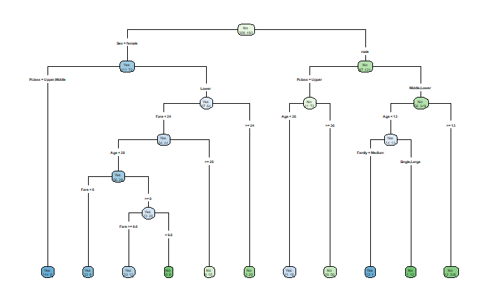

```r
library(rpart)
library(rpart.plot)
method3DT <- rpart(Survived ~ Pclass + Sex + Age + Fare + Embarked + Family, method3Train)
rpart.plot(method3DT, type = 4, extra = 1)
```

```r
dtPred <- predict(method3DT, method3Test, type = "class")
confusion <- table(Prediction = dtPred, Actual = method3Test$Survived)
confusion
```

```
          Actual
Prediction Yes No
       Yes  27  8
       No    7 48
```

```r
#Evaluation of model
TN <- confusion["No", "No"]
FN <- confusion["No", "Yes"]
TP <- confusion["Yes", "Yes"]
FP <- confusion["Yes", "No"]
dtAccuracy <- (TP + TN) / (TP + TN + FP + FN) #Accuracy
dtPrecision <- TP / (TP + FP) #Precision
dtRecall <- TP / (TP + FN) #Recall
dtF <- dtPrecision * dtRecall * 2/(dtPrecision + dtRecall) #F-Measure
#Computing the Chance Agreement
p1e <- (TN + FN)/(TP + TN + FP + FN) * (TN + FP)/(TP + TN + FP + FN)
p2e <- (TP + FP)/(TP + TN + FP + FN) * (TP + FN)/(TP + TN + FP + FN)
pe <- p1e + p2e
dtKappa <- (dtAccuracy - pe)/(1 - pe) #Kappa
dtAccuracy
```

```
[1] 0.8333333
```

```r
dtPrecision
```

```
[1] 0.7714286
```

```r
dtRecall
```

```
[1] 0.7941176
```

```r
dtF
```

```
[1] 0.7826087
```

```r
dtKappa
```

```
[1] 0.6475196
```

#### 5.3.3 SVM

```r
method3SVM <- svm(Survived ~ Pclass + Sex + Age + Fare + Embarked + Family, method3Train)
#Generating the prediction
svmPrediction <- predict(method3SVM, method3Test, type = "class")
#Builing the Confusion Matrix
confusion <- table(Prediction = svmPrediction, Actual = method3Test$Survived)
confusion
```

```
          Actual
Prediction Yes No
       Yes  25  7
       No    9 49
```

```r
#Evaluation of model
TN <- confusion["No", "No"]
FN <- confusion["No", "Yes"]
TP <- confusion["Yes", "Yes"]
FP <- confusion["Yes", "No"]
svmAccuracy = (TP + TN) / (TP + TN + FP + FN) #Accuracy
svmPrecision = TP / (TP + FP) #Precision
svmRecall = TP / (TP + FN) #Recall
svmF = svmPrecision * svmRecall * 2/(svmPrecision + svmRecall) #F-Measure
#Computing the Chance Agreement
p1e = (TN + FN)/(TP + TN + FP + FN) * (TN + FP)/(TP + TN + FP + FN)
p2e = (TP + FP)/(TP + TN + FP + FN) * (TP + FN)/(TP + TN + FP + FN)
pe = p1e + p2e
svmKappa = (svmAccuracy - pe)/(1 - pe) #Kappa
svmAccuracy
```

```
[1] 0.8222222
```

```r
svmPrecision
```

```
[1] 0.78125
```

```r
svmRecall
```

```
[1] 0.7352941
```

```r
svmF
```

```
[1] 0.7575758
```

```r
svmKappa
```

```
[1] 0.6174283
```

#### 5.3.4 Random Forest

```r
library(randomForest)

method3RF <- randomForest(Survived ~ Pclass + Sex + Age + Fare + Embarked + Family, method3Train)

#Generating the prediction
rfPrediction <- predict(method3RF, method3Test, type = "class")

#Builing the Confusion Matrix
confusion <- table(Prediction = rfPrediction, Actual = method3Test$Survived)
confusion

#Evaluation of model
TN <- confusion["No", "No"]
FN <- confusion["No", "Yes"]
TP <- confusion["Yes", "Yes"]
FP <- confusion["Yes", "No"]
rfAccuracy = (TP + TN) / (TP + TN + FP + FN) #Accuracy
rfPrecision = TP / (TP + FP) #Precision
rfRecall = TP / (TP + FN) #Recall
rfF = rfPrecision * rfRecall * 2/(rfPrecision + rfRecall) #F-Measure

#Computing the Chance Agreement
p1e = (TN + FN)/(TP + TN + FP + FN) * (TN + FP)/(TP + TN + FP + FN)
p2e = (TP + FP)/(TP + TN + FP + FN) * (TP + FN)/(TP + TN + FP + FN)
pe = p1e + p2e

rfKappa = (rfAccuracy - pe)/(1 - pe) #Kappa

rfAccuracy
rfPrecision
rfRecall
rfF
rfKappa
```

[output not shown]

#### 5.3.5 General Linear Model

```r
library(caTools)
#Builing the method3
method3Lr <- glm(Survived ~ Pclass + Sex + Age + Fare + Embarked + Family, method3Train, family = binomial)
#Generating the prediction
lrPrediction <- ifelse(predict(method3Lr,method3Test, type = 'response') > 0.5, 'No', 'Yes')
#Builing the Confusion Matrix
confusion <- table(Prediction = lrPrediction, Actual = method3Test$Survived)
confusion
```

```
          Actual
Prediction Yes No
       No    9 50
       Yes  25  6
```

```r
#Evaluation of method3
TN <- confusion["No", "No"]
FN <- confusion["No", "Yes"]
TP <- confusion["Yes", "Yes"]
FP <- confusion["Yes", "No"]
lrAccuracy = (TP + TN) / (TP + TN + FP + FN) #Accuracy
lrPrecision = TP / (TP + FP) #Precision
lrRecall = TP / (TP + FN) #Recall
lrF = lrPrecision * lrRecall * 2/(lrPrecision + lrRecall) #F-Measure
#Computing the Chance Agreement
p1e = (TN + FN)/(TP + TN + FP + FN) * (TN + FP)/(TP + TN + FP + FN)
p2e = (TP + FP)/(TP + TN + FP + FN) * (TP + FN)/(TP + TN + FP + FN)
pe = p1e + p2e
lrKappa = (lrAccuracy - pe)/(1 - pe) #Kappa
lrAccuracy
```

```
[1] 0.8333333
```

```r
lrPrecision
```

```
[1] 0.8064516
```

```r
lrRecall
```

```
[1] 0.7352941
```

```r
lrF
```

```
[1] 0.7692308
```

```r
lrKappa
```

```
[1] 0.6392304
```

# 6. Results and Evaluation

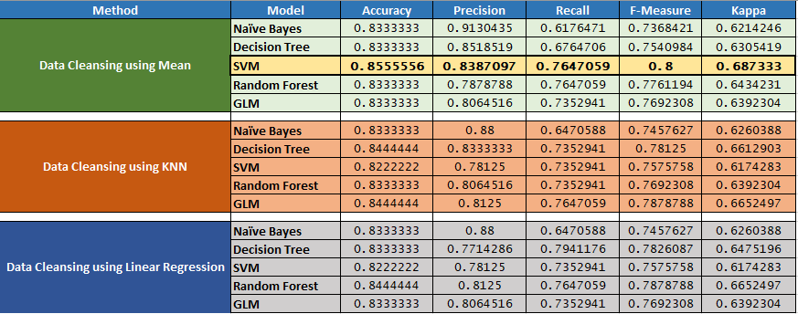

We have used three different methods to predict the missing values of age in our data. And build a classification model for each of these data cleansing methods.

First, we filled the missing values in Age and Fare by considering the mean of the attribute over the entire data and replaced the blank values in the Embarked attribute with the mode of that attribute. Then, using the cleaned training data we first build a Naive Bayes model which resulted in 83% in accuracy and 62% in Kappa, which is a fairly good model. Then, we used the same train and test data and build predictive models using Decision trees, SVM, Random Forest and general linear models. which provided Accuracy, precision, Recall, F-Measure and Kappa as shown in the above table. SVM proved to be the best model for this data cleansing method with 85% accuracy and 68% Kappa.

Then, in our second method, we built a predictive model for predicting the missing values of age, fare and embarked in our dataset with a hope that our model would make a better-educated guess. KNN algorithm generates groups of data based on the attributes and measuring the similarity by Euclidean distance. In this method, we also tried to categorize the instances of the attribute family into 3 classes, namely, Single, middle and large family. Again, separating the training data provided from this cleaner data, we build our train and test sets to build our models. Similar to the first method we built predictive models using Naive Bayes, Decision Trees, SVM, Random Forest and General Linear Models. In this method, GLM proved to be a better model with 84% accuracy and 66% Kappa value.

In our last method, we built a predictive model using regression to predict our missing age values. And similar to last two methods, we built predictive models using Naive Bayes, Decision Trees, SVM, Random Forest and General Linear Models. In this case, Random Forest turned out to be a winner with 84% accuracy and 66% Kappa. And, as we can see that in all of the models, Method 1 SVM performed the best with 85% accuracy and 68% Kappa.

As this result is based on the provided training data, we evaluated our best model on the given test data which yielded a result of 78.47% as shown in the image below. Currently, Kaggle is using just the 50% of the test data to evaluate the score of the model, the final results may improve if the remaining test data is used.

```r
dropsForSvm <- c("Survived")
svmTest <- method1DataTest[, !names(method1DataTest) %in% dropsForSvm]

SVMPredResult <- ifelse(predict(method1SVM, svmTest, type = "class") == "Yes", 1, 0)

SVMResult <- titanicTest
SVMResult$Survived <- SVMPredResult
write.csv(SVMResult, file = "SVMResult.csv", row.names = F)
```

[figure not shown]

# 7. Major Challenges

**Data Cleansing:**

In analyzing the data and building a predictive model to predict the outcome of any new instance whether or not that particular instance would survive, we realized that cleansing of the data properly is extremely important, not only because we could lose information but also some models cannot handle missing values in the data.

We felt cleaning the data as the most challenging task in our project, as we were unable to find the best way to tackle 263 missing age values from 1309 instances, which is 20% of the available data, and this number is huge when it comes to building predictive models.

We as humans prefer categorical data as it delivers more insight, but the algorithms prefer to work with numerical data. This often leads to unexpected results, as some of the instances draw the prediction towards them just due to their mass. This leads to a confusion, of which attributes should be kept categorical and which should be kept numerical.

**Availability of data:**

The Second challenge we faced is the availability of the data. Though our models almost reached 85% accuracy, we could have generated better model if the available data for training was more than 891 instances. In addition to this, the available data has 20% missing values for the attribute Age, which is one of the dominant attributes that contribute to the prediction of the passenger survival.

# 8. Conclusion

Based on our analysis we can interpret that the attributes such as the Gender, Age, Social status, number of family members onboard and the port of embarkation of a passenger provide us useful information about the demographics of the passenger and assists us in building an efficient model that would predict the chance of the passenger’s survival on the Titanic. However, the other attributes such as Ticket Number, cabinet and the name of the passenger are comparatively less dominant and provide no useful information towards the prediction of the survival rate.

While building the models we realized that the available data is not of prime quality, because of the inconsistencies in the available data such as 263 missing values of the attribute Age which is one of the important attributes. Also, the available instances for training the data was not sufficient enough to get the model to predict with an accuracy of more than 85%. In order to deal with this missing values in the attribute Age, we used three different methodologies to load the missing values that are the mean method, KNN, linear regression models. In the mean method, we replaced the missing values with the mean of the attributes that contain the missing values. KNN model was used as another method which predicted and replaced the missing values. At last, we built a regression model to predict the missing age values. For each of this method, we built Naive Bayes, Decision Tree, SVM, Random Forest and General Linear Models. On the evaluation of each model, we concluded that SVM proved to be a better model when the data cleansing was performed by the mean method. It was successful in achieving an accuracy of 85% and a kappa value of 68%. This can be improved by using feature selection methods, Feature engineering methods, which was not implemented in this project due to the limited amount of time.

Though we used predictive models to load missing values and assisting our models in taking a better-educated guess, the models did not differ much from the models that were built using the mean method. We believe that building a model to predict the missing age values based on Gender, social status and number of family members on board would never result in accurate determinations. Thus, assisting our argument of the need for more data.

We used 2 basic classification models and 3 advanced classification models in our analysis methods. Though we know that these models are efficient in the world of data analytics and machine learning, we believe that each model performs better for a particular type of data. In our case SVM proved to be the best model for predicting the survival of the passengers on Titanic is because our data was sparse in nature, easy to visualize and having a distinct boundary to separate the two classes of Yes and No. GLM and Random forest perform well when there are multi-dimensions in the data or visualizing the data are difficult, whereas the data we have is binary and limited. Naive Bayes is based on probability and would perform better in comparison to SVM when the data does not have a clear/distinct boundary, so will the Decision tree.

In conclusion, we would like to say, that working on this project had a great learning curve, we realized the importance of cleaning of the data, visualizing the attributes to understand the meaning and the relations behind them, the purpose of transforming the data provided to models to assist them in making better predictions.